# 02 - Data Visualization

Nhóm 17

2026-06-27

# 1. Chuẩn bị dữ liệu & Thư viện

Ở phần trước, dữ liệu đã được làm sạch và lưu trữ dưới dạng file `.rds` để bảo toàn kiểu dữ liệu và cấu trúc phân loại. Chúng ta sẽ tải các thư viện cần thiết và nạp dữ liệu sạch này để phục vụ cho các phân tích trực quan nâng cao.

```r
library(tidyverse)
library(scales)
library(ggthemes)
library(viridis)

# Nạp dữ liệu sạch từ Phần 1
freelancer <- readRDS("../data/freelancer_clean.rds")
```

# 2. Phân tích Trực quan hóa dữ liệu

## 2.1 So sánh thu nhập (Earnings_USD) theo các biến phân loại

Để so sánh trực quan và hiểu rõ sự biến động thu nhập theo từng nhóm, chúng ta sẽ kết hợp **Violin Plot** (thể hiện hình dạng mật độ phân phối) và **Boxplot** lồng bên trong (thể hiện các mốc thống kê quan trọng và giá trị ngoại lai).

### a. Theo Nền tảng (Platform)

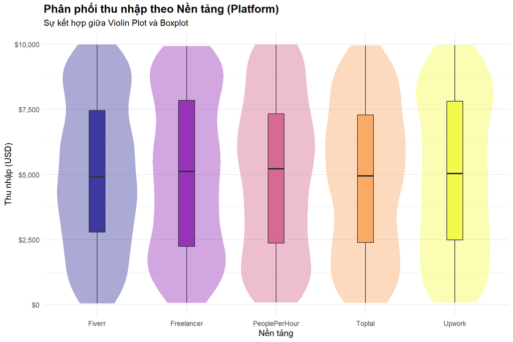

```r
ggplot(freelancer, aes(x = Platform, y = Earnings_USD, fill = Platform)) +
  geom_violin(alpha = 0.35, color = NA) +
  geom_boxplot(width = 0.18, alpha = 0.7, outlier.colour = "red", outlier.size = 1.2) +
  scale_y_continuous(labels = dollar) +
  scale_fill_viridis_d(option = "plasma") +
  labs(title = "Phân phối thu nhập theo Nền tảng (Platform)",
       subtitle = "Sự kết hợp giữa Violin Plot và Boxplot",
       x = "Nền tảng", y = "Thu nhập (USD)") +
  theme_minimal() +
  theme(legend.position = "none",
        plot.title = element_text(face = "bold", size = 14))
```

> **Nhận định chi tiết:**
> - **Quan sát trực quan:** Hình dáng của các biểu đồ Violin Plot gần như tương đồng nhau trên tất cả 5 nền tảng (Fiverr, Freelancer, Upwork, Toptal, PeoplePerHour). Không có nền tảng nào thể hiện sự phình to (tập trung đông đảo) ở một mức thu nhập cụ thể. Boxplot lồng bên trong cũng cho thấy mức thu nhập trung vị (đường gạch ngang đậm) dao động xoay quanh mốc $5,000 một cách khá đồng đều.
> - **Phân tích ý nghĩa:** Dữ liệu cho thấy nền tảng làm việc không tạo ra sự phân hóa quá lớn về mặt thu nhập. Một freelancer hoàn toàn có thể kiếm được mức thu nhập $10,000 (mức cao nhất) ở bất kỳ nền tảng nào, miễn là họ có chiến lược phù hợp. Sự biến thiên rộng từ $0 đến $10,000 cho thấy thu nhập phụ thuộc vào năng lực cá nhân thay vì “mác” của nền tảng.
> - **Hàm ý thực tiễn:** Đối với một freelancer mới bắt đầu, việc chọn nền tảng nào không quan trọng bằng việc xây dựng hồ sơ năng lực tốt. Không có nền tảng nào là “mỏ vàng” hiển nhiên, cũng không có nền tảng nào là “đáy” của thị trường.

### b. Theo Danh mục công việc (Job_Category)

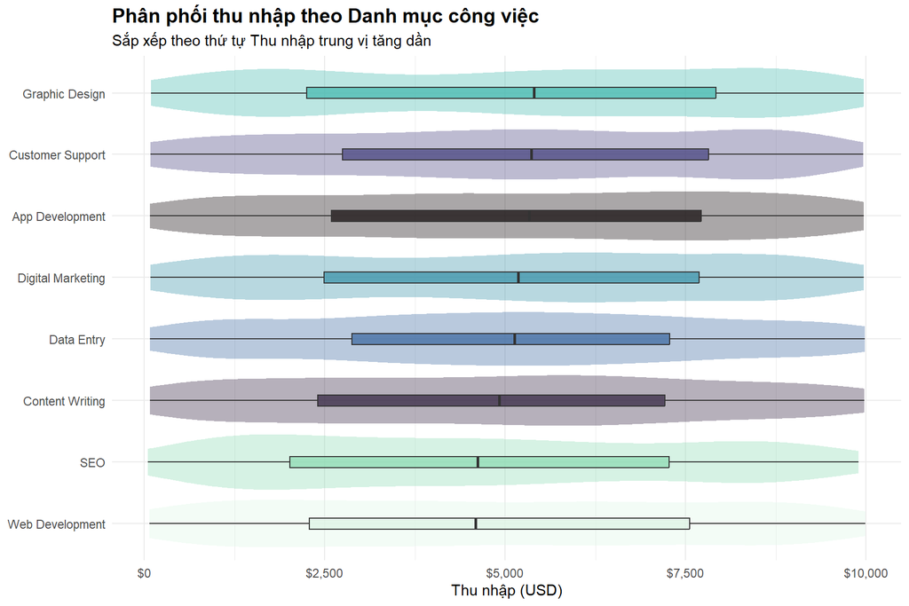

```r
ggplot(freelancer, aes(x = reorder(Job_Category, Earnings_USD, median), y = Earnings_USD, fill = Job_Category)) +
  geom_violin(alpha = 0.35, color = NA) +
  geom_boxplot(width = 0.18, alpha = 0.7, outlier.colour = "red", outlier.size = 1.2) +
  scale_y_continuous(labels = dollar) +
  scale_fill_viridis_d(option = "mako") +
  coord_flip() +
  labs(title = "Phân phối thu nhập theo Danh mục công việc",
       subtitle = "Sắp xếp theo thứ tự Thu nhập trung vị tăng dần",
       x = NULL, y = "Thu nhập (USD)") +
  theme_minimal() +
  theme(legend.position = "none",
        plot.title = element_text(face = "bold", size = 14))
```

> **Nhận định chi tiết:**
> - **Quan sát trực quan:** Dựa vào thứ tự trung vị tăng dần, trái với các dự đoán thông thường, các mảng dịch vụ và sáng tạo như *Graphic Design* hay *Customer Support* lại đang dẫn đầu về mức trung vị thu nhập (trên mức $5,000) — hộp Boxplot của chúng dịch chuyển rõ rệt về phía bên phải. Ngược lại, nhóm ngành công nghệ như *Web Development* và *SEO* lại nằm ở nửa dưới (đáy bảng) của biểu đồ. Dù vậy, hình dáng Violin của toàn bộ các nhóm ngành vẫn dàn trải đều từ $0 đến $10,000, không có ngành nào bị bó hẹp hoàn toàn ở phân khúc thấp.
> - **Phân tích ý nghĩa:** Kết quả này đi ngược lại với định kiến thông thường rằng lập trình IT luôn mang lại thu nhập cao nhất. Sự đảo ngược này cho thấy thị trường làm việc tự do có tính phân hóa đặc thù: ngành *Web Development* và *SEO* do có rào cản gia nhập ngày càng thấp (nhờ sự hỗ trợ của các công cụ low-code/no-code và AI) nên mức độ cạnh tranh và phá giá dịch vụ ở phân khúc phổ thông rất cao, làm giảm mức thu nhập trung vị. Ngược lại, các công việc sáng tạo (*Graphic Design*) hay đòi hỏi kỹ năng mềm tương tác cao (*Customer Support*) vẫn duy trì được đơn giá tốt và mang lại thu nhập ổn định nhờ vào tính chất công việc dài hạn (hợp đồng retainer/tính theo giờ liên tục).
> - **Hàm ý thực tiễn:** Freelancer không nhất thiết phlải “cố đấm ăn xôi” học các kỹ năng công nghệ cốt lõi nếu không có thế mạnh. Khai thác sâu vào mảng dịch vụ khách hàng hoặc thiết kế đồ họa bằng một khối lượng công việc đều đặn vẫn có thể mang lại mức thu nhập trung vị vượt trội hơn cả các lập trình viên. Tuy nhiên, cơ hội đạt mức thu nhập tối đa ($10,000) vẫn chia đều cho tất cả các ngành nhờ vào năng suất làm việc của từng cá nhân.

### c. Theo Khu vực khách hàng (Client_Region)

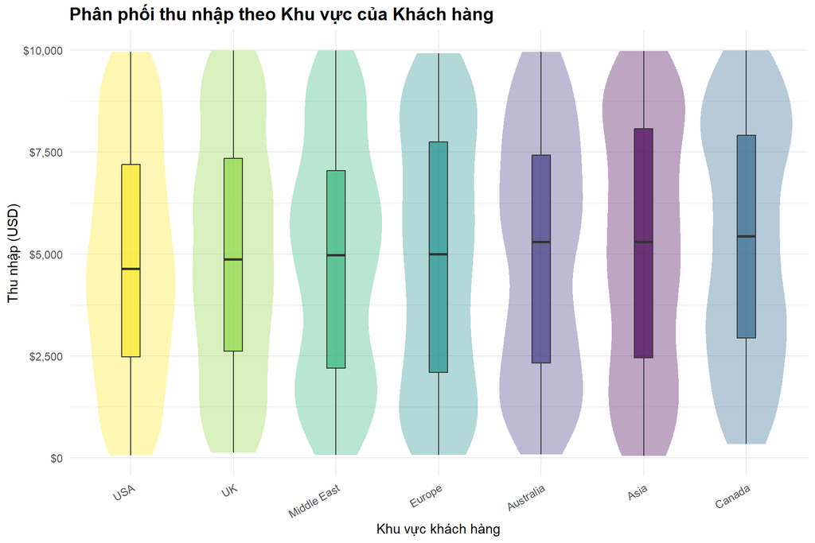

```r
ggplot(freelancer, aes(x = reorder(Client_Region, Earnings_USD, median), y = Earnings_USD, fill = Client_Region)) +
  geom_violin(alpha = 0.35, color = NA) +
  geom_boxplot(width = 0.18, alpha = 0.7, outlier.colour = "red", outlier.size = 1.2) +
  scale_y_continuous(labels = dollar) +
  scale_fill_viridis_d(option = "viridis") +
  labs(title = "Phân phối thu nhập theo Khu vực của Khách hàng",
       x = "Khu vực khách hàng", y = "Thu nhập (USD)") +
  theme_minimal() +
  theme(legend.position = "none",
        axis.text.x = element_text(angle = 30, hjust = 1),
        plot.title = element_text(face = "bold", size = 14))
```

> **Nhận định chi tiết:**
> - **Quan sát trực quan:** Biểu đồ thể hiện mức độ phân tán thu nhập cực kỳ đều đặn giữa các châu lục. Mặc dù Mỹ (USA) và Anh (UK) thường được coi là thị trường trả lương cao, biểu đồ Violin của họ không có sự khác biệt rõ nét so với các khu vực như Châu Á (Asia) hay Trung Đông (Middle East).
> - **Phân tích ý nghĩa:** Trong kỷ nguyên toàn cầu hóa của thị trường làm việc tự do (freelance), ranh giới địa lý và chênh lệch mức sống đã bị xóa nhòa đáng kể. Khách hàng từ Châu Á hoàn toàn có thể trả mức giá tương đương với khách hàng từ Châu Âu cho cùng một chất lượng công việc hoàn thành.
> - **Hàm ý thực tiễn:** Freelancer không nên giới hạn bản thân vào việc chỉ tìm kiếm khách hàng ở các quốc gia phương Tây với hy vọng có “thu nhập ngoại tệ cao”. Thay vào đó, hãy mở rộng tệp khách hàng trên toàn cầu, miễn là khách hàng có ngân sách tốt và dự án phù hợp với năng lực.

## 2.2 Mối quan hệ giữa Client_Rating và Rehire_Rate

Để kiểm tra giả thuyết: *“Freelancer được khách hàng đánh giá cao (Client_Rating) thì có tỷ lệ được thuê lại (Rehire_Rate) nhiều hơn không?”*, chúng ta thực hiện vẽ biểu đồ điểm phân tán.

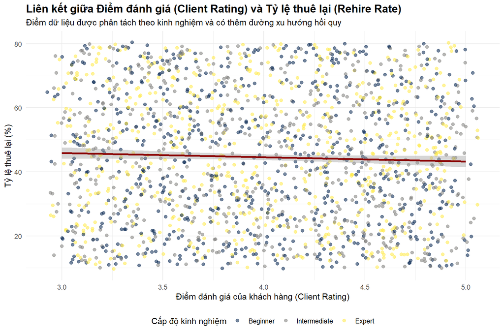

```r
ggplot(freelancer, aes(x = Client_Rating, y = Rehire_Rate, color = Experience_Level)) +
  geom_jitter(alpha = 0.55, size = 1.8, width = 0.08, height = 0.6) +
  geom_smooth(method = "lm", formula = y ~ x, color = "darkred", size = 1.2, se = TRUE) +
  scale_color_viridis_d(option = "cividis", name = "Cấp độ kinh nghiệm") +
  labs(title = "Liên kết giữa Điểm đánh giá (Client Rating) và Tỷ lệ thuê lại (Rehire Rate)",
       subtitle = "Điểm dữ liệu được phân tách theo kinh nghiệm và có thêm đường xu hướng hồi quy",
       x = "Điểm đánh giá của khách hàng (Client Rating)",
       y = "Tỷ lệ thuê lại (%)") +
  theme_minimal() +
  theme(legend.position = "bottom",
        plot.title = element_text(face = "bold", size = 14))
```

> **Nhận định chi tiết:**
> - **Quan sát trực quan:** Đồ thị phân tán (Scatter Plot) cho thấy sự hỗn loạn hoàn toàn của các điểm dữ liệu. Đường xu hướng (Trendline) màu đỏ nằm gần như ngang hoặc hơi dốc xuống một cách không đáng kể. Sự phân bố màu sắc (đại diện cho Cấp độ kinh nghiệm) hoàn toàn trộn lẫn vào nhau không theo quy luật.
> - **Phân tích ý nghĩa:** Trái với tư duy logic thông thường (“làm tốt, điểm cao thì sẽ được khách hàng thuê lại”), đồ thị chứng minh **không hề có tương quan tuyến tính** giữa điểm đánh giá (`Client_Rating`) và tỷ lệ tái hợp tác (`Rehire_Rate`). Một freelancer nhận đánh giá tuyệt đối 5 sao hoàn toàn có thể có tỷ lệ thuê lại ở mức rất thấp (20%), và ngược lại, người bị đánh giá 3 sao vẫn có thể được thuê lại tới 80%.
> - **Hàm ý thực tiễn:** Điều này ngụ ý rằng tỷ lệ quay lại của khách hàng phụ thuộc vào bản chất của dự án (ví dụ: dự án thiết kế bộ nhận diện thương hiệu thường chỉ làm 1 lần nên không có nhu cầu thuê lại) hoặc do yếu tố ngân sách cạn kiệt, chứ không nằm ở mức độ hài lòng về thái độ (thể hiện qua số sao). Freelancer không nên quá áp lực nếu tỷ lệ Rehire Rate của mình không cao.